# CPTS 475 Homework 3

Andrew Balaschak

2023-09-29

# 1.

Here is a description of the variables:

| Variable | Description |
| --- | --- |
| PLAYER | Name of the player |
| TEAM | Name of the team |
| AGE | Age of the player |
| GP | Games Played |
| W | Wins |
| L | Losses |
| MIN | Minutes Played |
| PTS | Points |
| FGM | Field Goals Made |
| FGA | Field Goals Attempted |
| X3PM | 3 Point Field Goals Made |
| X3PA | 3 Point Field Goals Attempted |
| FTM | Free Throws Made |
| FTA | Free Throws Attempted |
| OREB | Offensive Rebounds |
| DREB | Defensive Rebounds |
| REB | Rebounds |
| AST | Assists |
| TOV | Turnovers |
| STL | Steals |
| BLK | Blocks |
| PF | Personal Fouls |
| FP | Fantasy points |
| DD2 | Double Doubles |
| TD3 | Triple Doubles |

```r
library(dplyr)
nba_data <- read.csv("NBA_Stats_22_23.csv")
head(nba_data)
```

```
##              PLAYER TEAM AGE GP  W  L    MIN  PTS FGM FGA X3PM X3PA FTM FTA
## 1        AJ Griffin  ATL  19 72 34 38 1401.4  639 248 533  101  259  42  47
## 2     Aaron Holiday  ATL  26 63 32 31  845.3  247  92 220   36   88  27  32
## 3 Bogdan Bogdanovic  ATL  30 54 27 27 1508.6  756 273 611  146  360  64  77
## 4    Bruno Fernando  ATL  24 39 13 26  405.1  153  59 112    0    4  35  50
## 5      Clint Capela  ATL  29 65 35 30 1730.1  779 350 536    0    1  79 131
## 6   De'Andre Hunter  ATL  25 67 35 32 2125.6 1029 379 822  100  286 171 207
##   OREB DREB REB AST TOV STL BLK  PF   FP DD2 TD3
## 1   37  116 153  73  42  42  12  87 1052   0   0
## 2   25   49  74  89  36  37  12  79  580   0   0
## 3   23  142 165 150  65  43  18  86 1297   0   0
## 4   54   83 137  31  25   6  34  74  459   1   0
## 5  258  459 717  58  54  45  79 139 2044  35   0
## 6   46  238 284  94  82  35  17 199 1585   1   0
```

```r
nba_data %>% filter(FGM > 60, AST > 80)
```

```
##                       PLAYER TEAM AGE GP  W  L    MIN  PTS FGM  FGA X3PM X3PA
## 1              Aaron Holiday  ATL  26 63 32 31  845.3  247  92  220   36   88
## 2          Bogdan Bogdanovic  ATL  30 54 27 27 1508.6  756 273  611  146  360
## 3            De'Andre Hunter  ATL  25 67 35 32 2125.6 1029 379  822  100  286
## 4            Dejounte Murray  ATL  26 74 38 36 2693.4 1515 612 1319  133  387
## 5              Jalen Johnson  ATL  21 70 35 35 1041.6  395 158  322   30  104
## 6               John Collins  ATL  25 71 37 34 2129.6  931 359  707   70  240
## 7             Onyeka Okongwu  ATL  22 80 41 39 1848.6  791 317  497    4   13
## 8                 Saddiq Bey  ATL  24 77 24 53 2128.7 1062 353  836  151  418
## 9                 Trae Young  ATL  24 73 38 35 2540.7 1914 597 1390  154  460
## 10               Ben Simmons  BKN  26 42 24 18 1105.0  291 133  235    0    2
## 11       Dorian Finney-Smith  BKN  30 66 31 35 2008.8  551 196  501  114  338
## 12                Joe Harris  BKN  31 74 40 34 1527.2  562 201  440  142  333
## 13             Mikal Bridges  BKN  26 83 42 41 2963.2 1671 593 1267  169  442
## 14               Nic Claxton  BKN  24 76 41 35 2270.7  961 414  587    0    2
```

[output cut: 473 more lines]

## 1.b. Print the PLAYER, TEAM, W, L, FGM, TOV and PTS of the players with the 10 highest points, in descending order of points. Which player has the second highest points?

```r
nba_data %>% arrange(desc(PTS)) %>% select(PLAYER, TEAM, W, L, FGM, TOV, PTS) %>% slice(1:10)
```

```
##                     PLAYER TEAM  W  L FGM TOV  PTS
## 1             Jayson Tatum  BOS 52 22 727 213 2225
## 2              Joel Embiid  PHI 43 23 728 226 2183
## 3              Luka Doncic  DAL 33 33 719 236 2138
## 4  Shai Gilgeous-Alexander  OKC 33 35 704 192 2135
## 5    Giannis Antetokounmpo  MIL 47 16 707 246 1959
## 6          Anthony Edwards  MIN 40 39 707 259 1946
## 7            Julius Randle  NYK 44 33 658 216 1936
## 8         Donovan Mitchell  CLE 44 24 679 180 1922
## 9               Trae Young  ATL 38 35 597 300 1914
## 10             Zach LaVine  CHI 38 39 673 194 1913
```

Joel Embiid has the second highest point total at 2183

## 1.c. Add two new columns to the dataframe: FGP (in percentage) is the ratio of FGM to FGA, FTP (in percentage) is the ratio of FTM to FTA. What is the FGP and FTP for Joe Harris?

```r
nba_data <- nba_data %>% mutate(FGP = round((FGM / FGA) * 100, 2))
nba_data <- nba_data %>% mutate(FTP = round((FTM / FTA) * 100, 2))
print(nba_data)
```

```
##                       PLAYER TEAM AGE GP  W  L    MIN  PTS FGM  FGA X3PM X3PA
## 1                 AJ Griffin  ATL  19 72 34 38 1401.4  639 248  533  101  259
## 2              Aaron Holiday  ATL  26 63 32 31  845.3  247  92  220   36   88
## 3          Bogdan Bogdanovic  ATL  30 54 27 27 1508.6  756 273  611  146  360
## 4             Bruno Fernando  ATL  24 39 13 26  405.1  153  59  112    0    4
## 5               Clint Capela  ATL  29 65 35 30 1730.1  779 350  536    0    1
## 6            De'Andre Hunter  ATL  25 67 35 32 2125.6 1029 379  822  100  286
## 7            Dejounte Murray  ATL  26 74 38 36 2693.4 1515 612 1319  133  387
## 8           Donovan Williams  ATL  21  2  1  1    4.3    4   2    5    0    2
## 9           Garrison Mathews  ATL  26 54 16 38  686.3  257  73  201   63  180
## 10             Jalen Johnson  ATL  21 70 35 35 1041.6  395 158  322   30  104
## 11            Jarrett Culver  ATL  24 10  5  5  136.9   44  17   43    1   12
## 12              John Collins  ATL  25 71 37 34 2129.6  931 359  707   70  240
## 13            Onyeka Okongwu  ATL  22 80 41 39 1848.6  791 317  497    4   13
## 14                Saddiq Bey  ATL  24 77 24 53 2128.7 1062 353  836  151  418
```

[output cut: 1065 more lines]

```r
filter(nba_data, PLAYER == "Joe Harris")
```

```
##       PLAYER TEAM AGE GP  W  L    MIN PTS FGM FGA X3PM X3PA FTM FTA OREB DREB
## 1 Joe Harris  BKN  31 74 40 34 1527.2 562 201 440  142  333  18  28   23  141
##   REB AST TOV STL BLK  PF   FP DD2 TD3   FGP   FTP
## 1 164 101  41  34  13 140 1010   0   0 45.68 64.29
```

Joe Harris’s FGP is 45.68%, and his FTP is 64.29%

## 1.d. Display the average, min and max PF for each team, in descending order of the team average. You can exclude NAs for this calculation. Which team has the max PF?

```r
nba_data %>% group_by(TEAM) %>% summarise(avg_PF = mean(PF), min_PF = min(PF), max_PF = max(PF)) %>% arrange(desc(avg_PF))
```

```
## # A tibble: 30 × 4
##    TEAM  avg_PF min_PF max_PF
##    <chr>  <dbl>  <int>  <int>
##  1 NYK    115.       0    233
##  2 PHX    108.      32    190
##  3 NOP    106.       1    245
##  4 GSW    103.       0    229
##  5 OKC    102.       5    243
##  6 HOU    102.       1    258
##  7 PHI    102.       0    209
##  8 MIN    101.      10    272
##  9 LAC    101.       2    219
## 10 DEN     99.5      9    190
## # ℹ 20 more rows
```

NYK’s team has the highest average PF, at 114.94 points.

## 1.e. In question 1c, you added a new column called FTP. Impute the missing (or NaN) FTP values as the FGP (also added in 1c) multiplied by the average FTP for that team. Make a second copy of your dataframe, but this time impute missing (or NaN) FTP values with just the average FTP for that team. What assumptions do these data filling methods make? Which is the best way to impute the data, or do you see a better way, and why? You may impute or remove other variables as you find appropriate. Briefly explain your decisions.

```r
nba_data %>% group_by(TEAM) %>% mutate(FTP = ifelse(is.na(FTP), FGP / 100 * mean(FTP, na.rm = TRUE), FTP))
```

```
## # A tibble: 539 × 27
## # Groups:   TEAM [30]
##    PLAYER     TEAM    AGE    GP     W     L    MIN   PTS   FGM   FGA  X3PM  X3PA
##    <chr>      <chr> <int> <int> <int> <int>  <dbl> <int> <int> <int> <int> <int>
##  1 AJ Griffin ATL      19    72    34    38 1401.    639   248   533   101   259
##  2 Aaron Hol… ATL      26    63    32    31  845.    247    92   220    36    88
##  3 Bogdan Bo… ATL      30    54    27    27 1509.    756   273   611   146   360
##  4 Bruno Fer… ATL      24    39    13    26  405.    153    59   112     0     4
##  5 Clint Cap… ATL      29    65    35    30 1730.    779   350   536     0     1
##  6 De'Andre … ATL      25    67    35    32 2126.   1029   379   822   100   286
##  7 Dejounte … ATL      26    74    38    36 2693.   1515   612  1319   133   387
##  8 Donovan W… ATL      21     2     1     1    4.3     4     2     5     0     2
##  9 Garrison … ATL      26    54    16    38  686.    257    73   201    63   180
## 10 Jalen Joh… ATL      21    70    35    35 1042.    395   158   322    30   104
## # ℹ 529 more rows
## # ℹ 15 more variables: FTM <int>, FTA <int>, OREB <int>, DREB <int>, REB <int>,
## #   AST <int>, TOV <int>, STL <int>, BLK <int>, PF <int>, FP <int>, DD2 <int>,
## #   TD3 <int>, FGP <dbl>, FTP <dbl>
```

```r
nba_data %>% group_by(TEAM) %>% mutate(FTP = ifelse(is.na(FTP), mean(FTP, na.rm = TRUE), FTP))
```

```
## # A tibble: 539 × 27
## # Groups:   TEAM [30]
##    PLAYER     TEAM    AGE    GP     W     L    MIN   PTS   FGM   FGA  X3PM  X3PA
##    <chr>      <chr> <int> <int> <int> <int>  <dbl> <int> <int> <int> <int> <int>
##  1 AJ Griffin ATL      19    72    34    38 1401.    639   248   533   101   259
##  2 Aaron Hol… ATL      26    63    32    31  845.    247    92   220    36    88
##  3 Bogdan Bo… ATL      30    54    27    27 1509.    756   273   611   146   360
##  4 Bruno Fer… ATL      24    39    13    26  405.    153    59   112     0     4
##  5 Clint Cap… ATL      29    65    35    30 1730.    779   350   536     0     1
##  6 De'Andre … ATL      25    67    35    32 2126.   1029   379   822   100   286
##  7 Dejounte … ATL      26    74    38    36 2693.   1515   612  1319   133   387
##  8 Donovan W… ATL      21     2     1     1    4.3     4     2     5     0     2
##  9 Garrison … ATL      26    54    16    38  686.    257    73   201    63   180
## 10 Jalen Joh… ATL      21    70    35    35 1042.    395   158   322    30   104
## # ℹ 529 more rows
## # ℹ 15 more variables: FTM <int>, FTA <int>, OREB <int>, DREB <int>, REB <int>,
## #   AST <int>, TOV <int>, STL <int>, BLK <int>, PF <int>, FP <int>, DD2 <int>,
## #   TD3 <int>, FGP <dbl>, FTP <dbl>
```

The first method, FGP * mean FTP, assumes that there is a relationship between FGP and FTP and they are positively correlated with each other. This could potentially overestimate players with a high FGP and underestimate players with a low FGP. The second method, mean FTP, assumes that there is no such relationship and that the team average is a good approximation. This ignores the potential variability of FTP within each team and the fact that the average can be skewed by outliers.

# 2. For this question, you will first need to read section 12.6 in the R for Data Science book (http://r4ds.had.co.nz/tidy-data.html#case-study). Grab the dataset “who” from the tidyr package (tidyr::who), and tidy it as shown in the case study before answering the following questions.

```r
library(tidyr)
who <- tidyr::who
who <- who %>%
  pivot_longer(
    cols = new_sp_m014:newrel_f65,
    names_to = "key",
    values_to = "cases",
    values_drop_na = TRUE
  ) %>%
  mutate(
    key = stringr::str_replace(key, "newrel", "new_rel")
  ) %>%
  separate(key, c("new", "var", "sexage")) %>%
  select(-new, -iso2, -iso3) %>%
  separate(sexage, c("sex", "age"), sep = 1)

print(who)
```

```
## # A tibble: 76,046 × 6
##    country      year var   sex   age   cases
##    <chr>       <dbl> <chr> <chr> <chr> <dbl>
##  1 Afghanistan  1997 sp    m     014       0
##  2 Afghanistan  1997 sp    m     1524     10
##  3 Afghanistan  1997 sp    m     2534      6
##  4 Afghanistan  1997 sp    m     3544      3
##  5 Afghanistan  1997 sp    m     4554      5
##  6 Afghanistan  1997 sp    m     5564      2
##  7 Afghanistan  1997 sp    m     65        0
##  8 Afghanistan  1997 sp    f     014       5
##  9 Afghanistan  1997 sp    f     1524     38
## 10 Afghanistan  1997 sp    f     2534     36
## # ℹ 76,036 more rows
```

## 2.a. Explain why this line “mutate(key = stringr::str_replace(key,”newrel”, “new_rel”))” is necessary to properly tidy the data. What happens if you skip this line?

That line is necessary to tidy the data because it fixes the formatting to be consistent so that there is always an underscore between the variable for new and old cases and the type of TB. If skipped, then the data is parsed incorrectly, with “var” being populated with the sex and age values, and “sex” and “age” both being unpopulated.

## 2.b. How many entries are removed from the dataset when you set values_drop_na to true in the pivot_longer command (in this dataset)?

When we exclude the line to drop the incomplete rows, we end up with 405,440 rows, when those rows are dropped we end up with 76,046 rows meaning 329,394 entries are removed.

## 2.c. Explain the difference between an explicit and implicit missing value, in general. Can you find any implicit missing values in this dataset? If so, where?

Explicit missing values are the absence of a value that is instead filled by something like N/A or NaN. An implicit missing value, on the other hand, is the absence of something that is inferred by analysis, such as a missing year or range in values. There are some implicit missing variables in this dataset, for example Afghanistan year 2013 only has two rows, for children ages 0-14. Clearly there should be rows for people of other ages, but there are not.

## 2.d. Looking at the features (country, year, var, sex, age, cases) in the tidied data, are they all appropriately typed? Are there any features you think would be better suited as a different type? Why or why not?

The year feature should probably be an integer instead of a double and cases should also be an integer instead of a double. This is because we only need to use integers for these discrete measurements, as a decimal value would not be meaningful.

## 2.e. Produce a barplot to show the count of TB cases by gender for all countries. You can create side by side bars for the two genders.

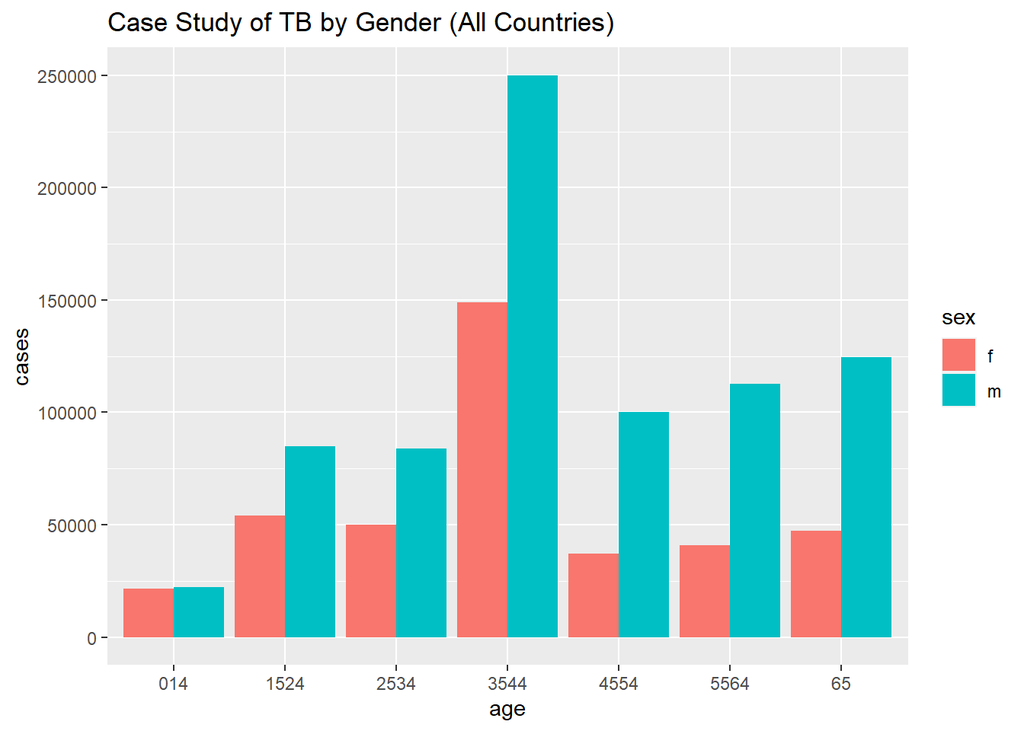

```r
library(ggplot2)
ggplot(who, aes(fill=sex, y=cases, x=age)) + geom_bar(position="dodge", stat="identity") + ggtitle("Case Study of TB by Gender (All Countries)")
```

## 2.f. The table consists of 6 columns. The first shows the Group code, the second shows the year and the last four columns provide the revenue for each quarter of the year. Re-structure this table and show the code you would write to tidy the dataset (using gather()/pivot_longer() and separate()/pivot_wider()) such that the columns are organized as: Group, Year, Interval_Type, Interval_ID and Revenue. How many rows does the new dataset have?

```r
revqtr <- read.csv("RevQtr.csv")
print(revqtr)
```

```
##    Group Year Qtr.1 Qtr_2 Qtr.3 Qtr.4
## 1      1 2019    27    90    12    84
## 2      2 2019    42    27    62    19
## 3      3 2019    26    51    58     8
## 4      1 2020    54    70    60    39
## 5      2 2020    17    20    45    99
## 6      3 2020    39    91    78    38
## 7      1 2021    26    66    42    26
## 8      2 2021    51    48    29    34
## 9      3 2021    71    31    30    56
## 10     1 2022    45    11    39    81
## 11     2 2022    65    26    82    48
## 12     3 2022    22    69    48    38
```

```r
revqtr <- gather(revqtr, Interval, Revenue, Qtr.1:Qtr.4)
separate(revqtr, Interval, c("Interval Type", "Interval ID"), convert = TRUE)
```

```
##    Group Year Interval Type Interval ID Revenue
## 1      1 2019           Qtr           1      27
## 2      2 2019           Qtr           1      42
## 3      3 2019           Qtr           1      26
## 4      1 2020           Qtr           1      54
## 5      2 2020           Qtr           1      17
## 6      3 2020           Qtr           1      39
## 7      1 2021           Qtr           1      26
## 8      2 2021           Qtr           1      51
## 9      3 2021           Qtr           1      71
## 10     1 2022           Qtr           1      45
## 11     2 2022           Qtr           1      65
## 12     3 2022           Qtr           1      22
## 13     1 2019           Qtr           2      90
## 14     2 2019           Qtr           2      27
```

[output cut: 34 more lines]

The new dataset has 48 rows.